# Forecasting Cyclist Traffic

Forecasting Daily Cyclist Volumes on the Johnson Street Bridge

Author

Tyler Stigall

Published

July 28, 2026

## 1 Project Overview

### 1.1 Victoria’s Critical Active Transportation Artery

- The **Johnson Street Bridge** serves as a vital multi-use link connecting downtown Victoria with regional trail networks.
- **Objective:** Build an end-to-end predictive pipeline to forecast daily cyclist volumes.
- **Business Value:** Empower infrastructure management to optimize seasonal maintenance windows and accurately evaluate environmental transit ROI.

## 2 Preliminaries

### 2.1 Data

As shown below, the time series shows high-frequenzy daily cyclist volumes over approximately 5 years. The series exhibits strong seasonality, with the primary variation appearing in days, and appears to be generally increasing over time. An interesting observation of this data is that the minimum number of cyclists appear to remain constant across time, while the maximum number of cyclists increases over time.

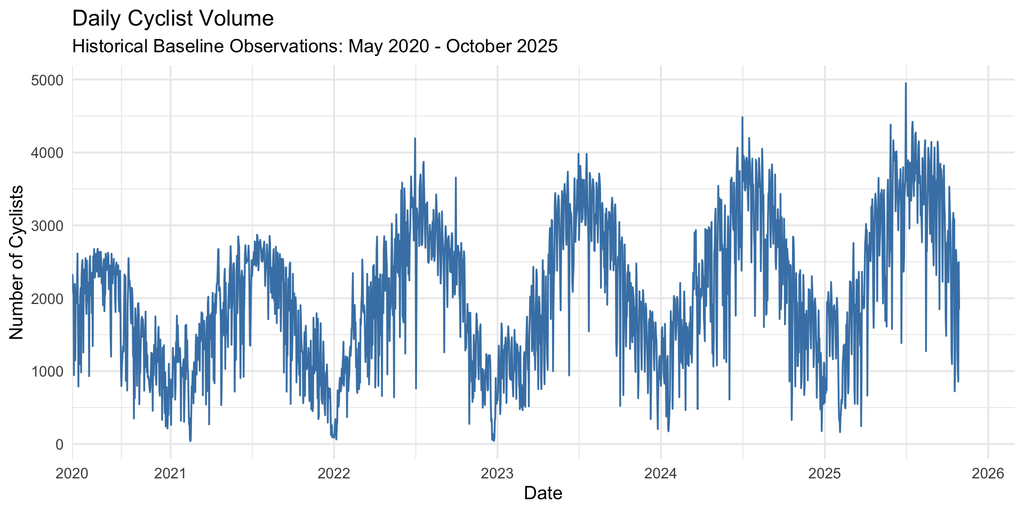

In addition, unit root testing (using both Augmented Dickey Fuller (ADF) and Kwiatkowski-Phillips-Schmidt-Shin (KPSS) tests) suggests that the number of cyclists is a unit root process as we fail to reject the null of non-stationarity in the ADF test but reject the null of stationarity in the KPSS test.

Stationarity Tests for Daily Cyclist Volume

Joint Diagnostics for Unit Roots and Trend Stationary Dynamics

| Diagnostic Test | Null Hypothesis (H₀) | Test Statistic | p-value |
| --- | --- | --- | --- |
| Augmented Dickey-Fuller (ADF) | Series possesses a unit root (Non-Stationary) | −3.1915 | 0.0894 |
| Kwiatkowski-Phillips-Schmidt-Shin (KPSS) | Series is stationary around a trend (Stationary) | 0.2369 | 0.0100 |

The ACF plot shows slow decay in the residuals, with spikes every seven days (each week), which indicates weekly dependence. The PACF plot shows that the first lag is the most important, and suggests that including at least 14 lags is important, as the 14th lag still has significance.

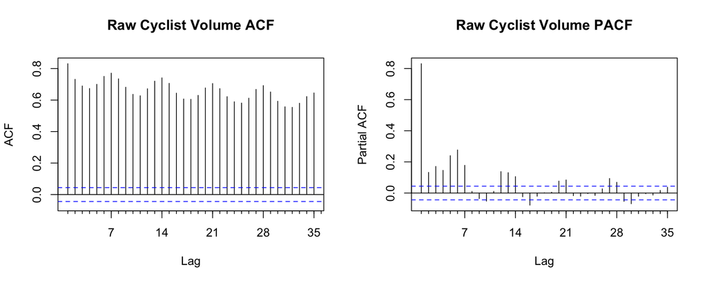

### 2.2 Variables

Exogenous weather variables are collected, including Mean Temperature (°C), Precipitation (mm), and Wind Speed (km/h). I also include indicators for days and months. I chose March as the baseline month since roughly half of the months were higher or below, and the same for Friday.

Unlike heavy rail or closed motor vehicles, cyclists are directly exposed to the surrounding climate. This exposure introduces high-dimensional volatility; microclimatic shifts in rainfall duration, ambient temperature bounds, wind speeds, and even daylight changes may create massive fluctuations in cyclist demand. Furthermore, research demonstrates that even incorrect public weather forecasts or heavy cloud visuals actively alter a cyclist’s morning modal choice before they leave the house. Therefore, we will include weather data, which will be forecasted weather data, and other exogenous controls to capture these environmental and temporal effects.

## 3 Model Selection

### 3.1 ARIMA

Forecasting cyclist counts requires a statistical framework that can handle both historical momentum and external disruptions. The ARIMAX model, which stands for AutoRegressive Integrated Moving Average with Exogenous Inputs, is an extension of standard time series modeling.

The autoregressive part captures the internal momentum, meaning that the number of riders on a trail today is often heavily related to how many people were riding yesterday. The integrated component applies differencing to stabilize the data, attempting to solve the serial correlation, stripping out long-term trends or seasonal shifts so the statistical properties remain constant over time. The moving average section corrects for sudden, short-term shocks to the system, like a minor traffic delay or a one-off event, by analyzing past forecast errors. Finally, the exogenous inputs act as the external anchors, allowing the model to incorporate outside datasets directly into the mathematical equation.

The foundational step involves checking for stationarity, typically via an Augmented Dickey-Fuller test, to ensure the data does not exhibit a continuous upward or downward drift that could bias our coefficients.

Once the model is fitted, the focus shifts entirely to the residuals, which are the differences between the predicted counts and the actual observed numbers. These residuals should behave as white noise, meaning they are completely random, unbiased, and contain no lingering information.

Now, the diagnostic testing for the ARIMAX model.

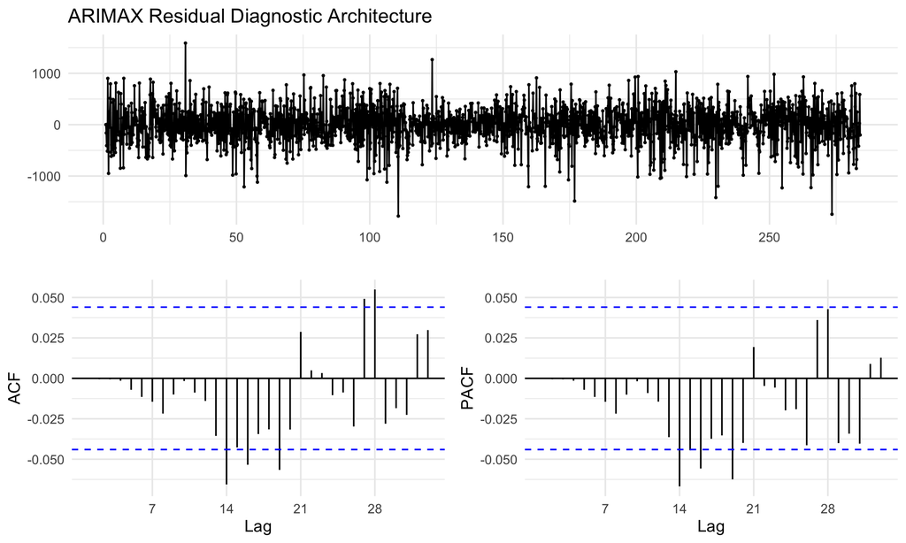

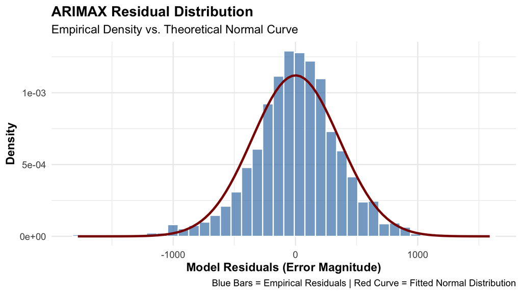

Evaluating the residual diagnostic architecture provides a transparent look into the health and mathematical validity of the fitted ARIMAX model before generating out-of-sample forecasts. The primary objective of this diagnostic phase is to verify that the model has successfully extracted all predictable systemic information from the historical dataset, leaving behind errors that behave purely as white noise.

Inspection of the ACF and PACF plots demonstrates the correlation coefficients across almost all immediate lags are successfully suppressed within the dashed statistical significance thresholds.

### 3.2 OLS

The value of forecasting does not have to just derive from prediction accuracy. Forecasting does not have to be independent of an attempt of causal inference, and some cases gives opportunity to be an extension of the modelling process. In the case of forecasting cyclist traffic, our goal is not just to give an accurate prediction of the number of cyclists on a specific day, but to understand the underlying mechanisms that are driving cyclist traffic.

This allows for the creation of policies that adapt to the underlying mechanisms that may shift in response to an exogenous shock, such as expanded bike infrastructure. This will help bridge the common pitfall of structural breaks rendering an accurate model nearly useless.If we can understand the underlying mechanisms that drive cyclist demand, we can better adapt to these structural breaks and create more robust forecasts.

To address this, we will use Linear Regression (OLS) as it is highly interpretable.

One issue with OLS for causal inference in time series is, the assumption that the error on any given day ($\epsilon_t$) tells you nothing about the error on the next day. This is highly unlikely in time series and this violation is serial correlation, or that other days will impact today. This will deflate the standard errors, making our coefficients seem more statistically significant than they are.

With this in mind, it is not a large issue for forecasting and we won’t make any causal claims.

To begin, I estimate an OLS model with the exogenous weather variables and indicators for days and months.

A few interesting patterns emerge. Firstly, it seems that the weather coeffieints are consistent with theory. Ridership increases with temperature (though here it is linear though likely is quadratic), and decreases with precipitation and wind. This is consistent across our months, as spring and summer months have higher ridership than that of those in the winter months.

If you look at just the day section, it looks like this route is primarily used by commuters, as the weekends are lower than Friday but most weekdays are associated with higher cyclist counts, on average. This is an important observation in itself, as it suggests targeting commuter ridership uses this infrastructure more than recreational riders.

OLS Baseline Parameter Architecture

Expanded Elasticities & Model Diagnostics

|  | estimate | [] |
| --- | --- | --- |
| Baseline Intercept | 1591.78173254341 | Meteorological Drivers |
| Mean Temperature (°C) | 66.6918969292298 | Meteorological Drivers |
| Precipitation (mm) | -39.0876575708138 | Meteorological Drivers |
| Wind Speed (km/h) | -19.9141930819798 | Meteorological Drivers |
| January | -370.745427168973 | Monthly Seasonal Adjustments (March Baseline) |
| February | -318.692579547826 | Monthly Seasonal Adjustments (March Baseline) |
| April | 259.541867964213 | Monthly Seasonal Adjustments (March Baseline) |
| May | 382.049254686564 | Monthly Seasonal Adjustments (March Baseline) |
| June | 391.21353778913 | Monthly Seasonal Adjustments (March Baseline) |
| July | 506.966609353103 | Monthly Seasonal Adjustments (March Baseline) |

[output cut: 11 more lines]

**Model Fit Diagnostics:**  
Observations: 1,952 | R²: 0.73 | Adj. R²: 0.727 | RMSE: 499.48 | AIC: 29,841.3 | BIC: 29,964

### 3.3 XGBoost

The Extreme Gradient Boosting framework approaches urban transit forecasting by building a sequential chain of shallow decision trees that iteratively correct past errors. This strategy makes it exceptionally well-suited for capturing sharp, non-linear thresholds in human behavior—such as the exact rainfall volume that causes commuting habits to shift—without requiring manual interaction terms.

By mapping high-dimensional interactions between temporal schedules and meteorological conditions, the model automatically recognizes that an increase in ambient temperature alters cyclist counts differently on a weekend morning than it does during a midweek commuter rush. It creates localized boundaries that adapt to volatile microclimatic shifts without suffering from the rigid assumptions of global parameters.

## 4 Backtesting

In time series forecasting, we can’t rely on a standard train-test split where you randomly shuffle your data. Because time has a strict direction, shuffling would let your model “peek into the future” to predict the past, known as data leakage.

That is where backtesting comes in. It is the process of testing a forecasting model’s predictive accuracy by simulating how it would have performed historically using actual past data.

It is a critical step in time series analysis, as it allows us to evaluate the model’s performance on unseen data and ensure that it generalizes well to future observations. While a model that backtests well is not guaranteed to perform well in the future, it is a strong indicator of its potential effectiveness.

Additionally, it helps prevent overfitting, as we can assess how well the model captures underlying patterns without being overly influenced by noise in the training data.

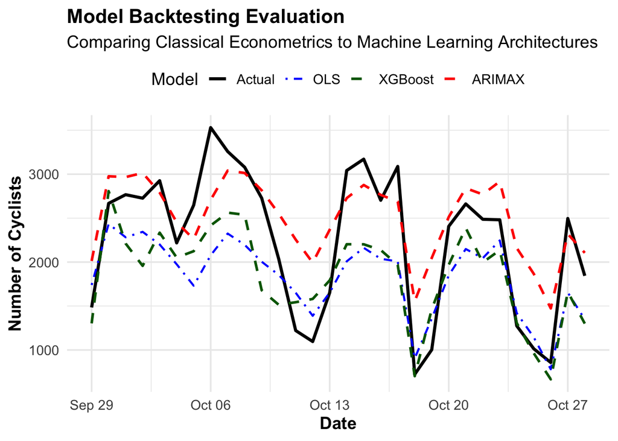

## 5 Forecasting

Now to the fun part.

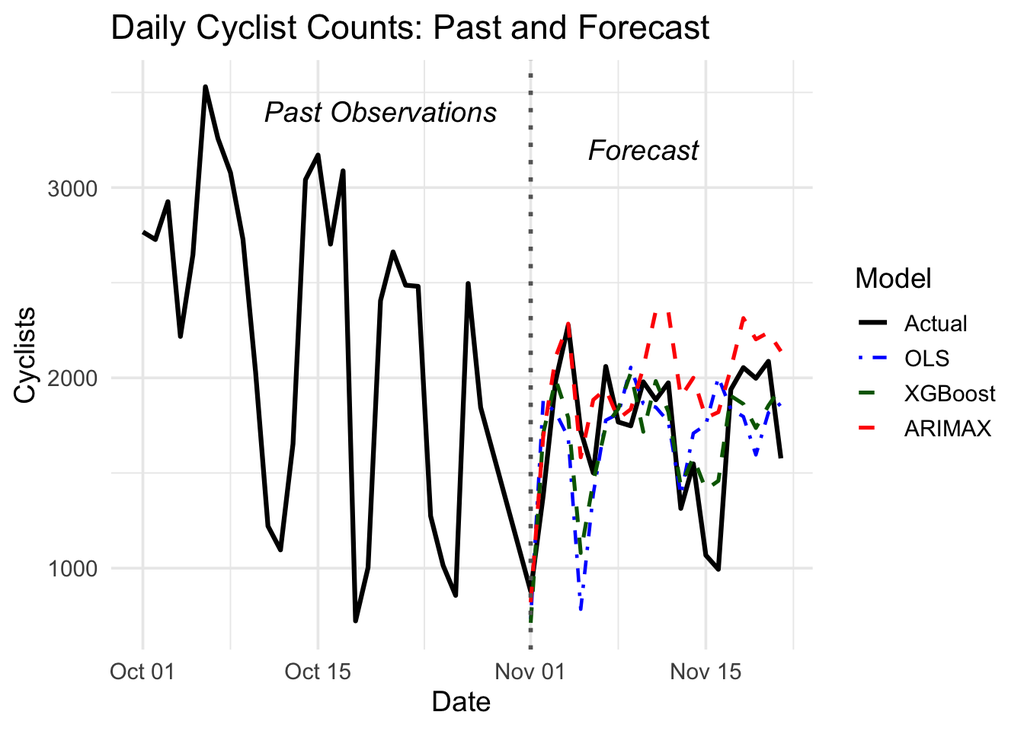

### 5.1 Evaluating Forecasts

How did the models preform? This is answered with a battery of metrics. We should not put too much stake in any single metric, but take into account all of our metrics.

If we consider the task of forecasting as if we were medical doctors, metrics are just symptoms of the model’s health (performance), and we need to factor several symptoms (metrics) together to get a holistic diagnosis of the model’s health (performance). We combine these evaluation metrics with our diagnostic testing for model assumptions to get a complete picture of model health.

The metrics we will use are:

Mean Absolute Error (MAE) measures the average magnitude of the errors in a set of forecasts, without considering their direction. It is the average of the absolute differences between the actual values ($y_t$) and predicted values ($\hat{y}_t$). The formula for MAE is:

$$MAE = \frac{1}{n} \sum_{t=1}^{n} |y_t - \hat{y}_t|$$

This treats all erros linearly, meaning that an error of say 50 cyclists is considered twice as bad as an error of 25 cyclists.

One benefit is that we are using the exact units as the original data, which makes it easy to interpret. However, it does not penalize larger errors more than smaller ones. So, if our model is way off when there is lots of rain, we don’t penalize that specifically.

Root Mean Squared Error (RMSE) squares the errors before averaging them, and then takes the square root of the final result.

$$RMSE = \sqrt{\frac{1}{n} \sum_{t=1}^{n} (y_t - \hat{y}_t)^2}$$
The Intuition: Because the errors are squared before they are averaged, RMSE puts a much heavier penalty on large errors. An error of 10 results in a penalty of 100, while an error of 5 is only 25.

Like MAE, it expresses the error in the original data units. However, it heavily penalize large, systemic misses or unexpected spikes. If our MAE is better than our RMSE, it indicates that we have a few large misses that are dragging down our RMSE.

A single massive outlier during an unusual event (like a holiday or a sudden data anomaly) can skew the RMSE upward, making a generally excellent model look terrible.

Mean Absolute Percentage Error (MAPE) solves the scale problem by expressing the error as a percentage of the actual values. Rather than looking at nominal values, it looks at relative values. It is the average of the absolute percentage differences between the actual values ($y_t$) and predicted values ($\hat{y}_t$).

$$MAPE = \frac{100\%}{n} \sum_{t=1}^{n} \left| \frac{y_t - \hat{y}_t}{y_t} \right|$$
This gives an idea about how far off we are, on average. Being off by 10 units when the actual value is 100 (10% error) is treated the same as being off by 100 units when the actual value is 1,000.

This is a very intuitive metric, since being off by 10% on average gives a better clue than 10 units. It also lets you compare model performance across entirely different time series with different scales.

The division by $y_t$ is scary, since if our observations are close to 0, we can get a huge error. We also need to make sure that $y_t$ is never 0, since we can’t divide by 0. In our case, we are safe, since we have no days with 0 cyclists.

### 5.2 How did the models perform?

The out-of-sample evaluation metrics for the three models are summarized in the table below. The metrics are calculated based on the forecasts made for November 2025, comparing the predicted cyclist volumes against the actual observed values.

```r
#| echo: false
#| include: false

library(gt)
library(dplyr)

# Convert the matrix into a clean dataframe for table formatting[cite: 5]
metrics_df <- as.data.frame(final_metrics) %>%
  tibble::rownames_to_column(var = "Model Architecture")

# Create a professional HTML table
metrics_df %>%
  gt() %>%
  tab_header(
    title = "November 2025 Production Evaluation Results",
    subtitle = "Johnson Street Bridge Daily Cyclist Volume Forecasts"
  ) %>%
  fmt_number(
    columns = c(MAE, RMSE),
    decimals = 2
  ) %>%
  fmt_number(
    columns = MAPE,
    decimals = 2,
    pattern = "{x}%"
  ) %>%
  tab_style(
    style = cell_text(weight = "bold"),
    locations = cells_column_labels()
  ) %>%
  tab_options(
    table.width = pct(100),
    column_labels.background.color = "#f8f9fa", # 🔥 Fixed the argument name here
    heading.title.font.size = px(18)
  )
```

November 2025 Production Evaluation Results

Johnson Street Bridge Daily Cyclist Volume Forecasts

| Model Architecture | MAE | RMSE | MAPE |
| --- | --- | --- | --- |
| Linear Regression (OLS) | 318.65 | 418.81 | 21.51% |
| XGBoost (Machine Learning) | 233.18 | 285.63 | 14.99% |
| ARIMAX(14,1,1)(1,0,0) | 287.36 | 370.29 | 20.21% |

The ARIMAX model, while performing better than OLS, still lagged behind XGBoost, indicating that the inclusion of exogenous variables alone was not sufficient to achieve optimal forecasting accuracy.

One important note with this sort of open forecasting, where we depend on a forecast for one or more of our independent variables such as weather, it that the accuraccy of each model is contingent on the accuracy of the forecasts for those independent variables. If the weather forecast is off, then our cyclist volume forecast will also be off. This is a limitation of any model that relies on exogenous inputs.

Now consider how close the forecasts were between XGBoost and OLS.

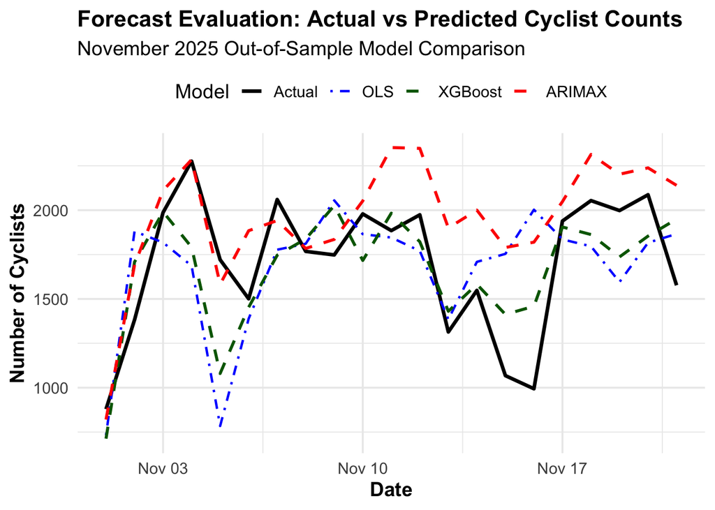

```r
ggplot(plot_data, aes(x = date, y = Cyclists, group = Model)) +
  geom_line(aes(color = Model, linetype = Model, size = Model)) +
  scale_color_manual(values = c("Actual" = "black", "OLS" = "blue", "XGBoost" = "darkgreen", "ARIMAX" = "red")) +
  scale_linetype_manual(values = c("Actual" = "solid", "OLS" = "dotdash", "XGBoost" = "dashed", "ARIMAX" = "dashed")) +
  scale_size_manual(values = c("Actual" = 1.2, "OLS" = 0.8, "XGBoost" = 1, "ARIMAX" = 1)) +
  labs(
    title = "Forecast Evaluation: Actual vs Predicted Cyclist Counts",
    subtitle = "November 2025 Out-of-Sample Model Comparison",
    x = "Date",
    y = "Number of Cyclists"
  ) +
  theme_minimal(base_size = 14) +
  theme(
    plot.title = element_text(face = "bold", size = 16),
    axis.title = element_text(face = "bold"),
    legend.position = "top"
  )
```

Both architectures track the same sudden dips and peaks across the November production window because they share a fundamental reliance on identical exogenous features. Unlike the ARIMAX framework, which derives its momentum from its own historical lags, both OLS and XGBoost evaluate each day based purely on the structural conditions provided to them, such as calendar indicators and daily weather variations. When a sharp weather event or a weekend shift occurs, both models immediately react to the exact same external shocks.

This overlapping behavior strongly suggests that the primary relationships driving daily cyclist volumes are predominantly linear and additive in nature. While XGBoost is a highly flexible and is able to capture non-linear interactions, it will approximate simpler, linear-like step functions if the true underlying data-generating process does not demand high-dimensional complexity.

The fact that XGBoost yields a superior set of evaluation metrics despite looking visually twins with OLS indicates that it is not discovering an entirely separate seasonal trend, but is instead handling the extreme boundaries of the data more effectively. Where the rigid assumptions of OLS cause it to overshoot or over-penalize on volatile days, the tree-based structure of XGBoost keeps its predictions more tightly bounded, capturing subtle thresholds in commuter behavior without losing the shared structural signal.

## 6 Conclusion

The development and deployment of this end-to-end time series pipeline provides a rigorous, data-driven framework for understanding and predicting daily cyclist volumes on the Johnson Street Bridge infrastructure. By evaluating and benchmarking classical econometric architectures against advanced machine learning methodologies, this investigation uncovers critical structural insights that balance forecasting accuracy with policy legibility.

The empirical results from the production window demonstrate that while each model successfully captured the overarching rhythm of urban active transportation, their operational mechanics yielded distinct performance profiles. The classical Ordinary Least Squares architecture provided a highly interpretable baseline, confirming fundamental economic and behavioral theories. The model clearly quantified how microclimatic volatility—specifically ambient temperature bounds, rainfall accumulation, and wind velocity—directly alters a cyclist’s morning modal choice before commuting. Furthermore, the temporal variables within the OLS framework mathematically isolated a heavy midweek commuter pattern, indicating that the bridge serves primarily as a critical occupational artery rather than a purely recreational pathway.

From an urban planning perspective, the implications of these models extend far beyond simple numerical accuracy. Because both the econometric and machine learning frameworks share a heavy reliance on identical exogenous features, their shared movements prove that daily cycling demand is highly sensitive to immediate environmental shocks. This sensitivity highlights a common pitfall in municipal planning: relying on static historical averages can leave cities unprepared for rapid shifts in transit behavior. By deploying this analysis, Municipalities can utilize these daily volume projections to optimize seasonal maintenance windows, manage trail congestion, allocate safety resources, and accurately evaluate the return on investment for expanded active transportation networks. Most importantly, understanding the underlying environmental and temporal mechanisms driving demand allows policymakers to better anticipate structural breaks, such as sudden shifts following the installation of protected bike lanes, ensuring that long-term urban planning remains resilient, proactive, and effective.